# Notebook

**Multivariate Vorhersagen verstehen**

Dr. Matthias Hölzl

## Was wir bereits wissen

- Univariate Regression: Eine Eingabe → Eine Ausgabe
- Beispiel: `Lieferzeit = 2 × Entfernung + 10`
- Wir haben bereits multivariate Modelle mit Scikit-Learn trainiert
- Aber wie funktionieren sie wirklich?

## Erinnerung: Univariate Regression

Pizza-Lieferzeit basierend auf Entfernung: Einfaches univariates Modell

```python
distance = 5.0  # km
coefficient = 2.0  # minutes per km
intercept = 10.0  # base time in minutes
```

```python
delivery_time = coefficient * distance + intercept
```

Entfernung ist das einzige Feature:

```python
distance
```

```
5.0
```

Als Ergebnis erhalten wir die vorhergesagte Lieferzeit:

```python
delivery_time
```

```
20.0
```

## Von einem zu mehreren Features

Was beeinflusst die Lieferzeit noch?

- Entfernung (km)
- Verkehrslage (0-10 Skala)
- Anzahl der Pizzen Wir haben jetzt mehrere Features!

```python
distance = 5.0
traffic = 7.0  # heavy traffic
num_pizzas = 3
```

Wie kombinieren wir diese?

## Multivariate Vorhersage: Die Idee

Jedes Feature trägt zur Vorhersage bei:

- Jedes Feature hat einen eigenen Koeffizienten
- Wir multiplizieren Feature × Koeffizient
- Dann addieren wir alle Beiträge

## Beispiel: Pizza-Lieferzeit mit 3 Features

Gegebene Modellkoeffizienten (bereits trainiert)

```python
coef_distance = 2.0    # minutes per km
coef_traffic = 1.5     # minutes per traffic unit
coef_pizzas = 0.5      # minutes per pizza
intercept = 8.0        # base time
```

Features für eine Bestellung

```python
distance = 5.0
traffic = 7.0
num_pizzas = 3
```

Berechne Vorhersage Schritt für Schritt

```python
contribution_distance = coef_distance * distance
contribution_traffic = coef_traffic * traffic
contribution_pizzas = coef_pizzas * num_pizzas
```

```python
print(f"Distance contribution: {coef_distance} × {distance} = {contribution_distance} min")
print(f"Traffic contribution: {coef_traffic} × {traffic} = {contribution_traffic} min")
print(f"Pizza contribution: {coef_pizzas} × {num_pizzas} = {contribution_pizzas} min")
print(f"Base time (intercept): {intercept} min")
```

```
Distance contribution: 2.0 × 5.0 = 10.0 min
Traffic contribution: 1.5 × 7.0 = 10.5 min
Pizza contribution: 0.5 × 3 = 1.5 min
Base time (intercept): 8.0 min
```

```python
total_time = contribution_distance + contribution_traffic + contribution_pizzas + intercept
```

```python
print(f"\nTotal predicted time: {total_time} minutes")
```

```
Total predicted time: 30.0 minutes
```

## Das Muster erkennen

Die Berechnung folgt immer dem gleichen Muster:

1. Multipliziere jedes Feature mit seinem Koeffizienten
2. Addiere alle Produkte
3. Addiere den Intercept

## Mit Listen organisieren

- Organisiere Features und Koeffizienten als Listen

```python
features = [distance, traffic, num_pizzas]
coefficients = [coef_distance, coef_traffic, coef_pizzas]  # corresponding coefficients
intercept = 8.0
```

```python
feature_names = ["distance_km", "traffic_level", "num_pizzas"]
```

Berechne mit Listen

```python
prediction = 0
for i in range(len(features)):
    contribution = features[i] * coefficients[i]
    prediction += contribution
    print(f"Feature {i}: {features[i]} × {coefficients[i]} = {contribution}")
```

```
Feature 0: 5.0 × 2.0 = 10.0
Feature 1: 7.0 × 1.5 = 10.5
Feature 2: 3 × 0.5 = 1.5
```

```python
prediction += intercept
print(f"Plus intercept: {intercept}")
print(f"Total prediction: {prediction}")
```

```
Plus intercept: 8.0
Total prediction: 30.0
```

## Kompaktere Schreibweise

- Verwende zip um Features mit Koeffizienten zu paaren

```python
prediction = sum(f * c for f, c in zip(features, coefficients)) + intercept
```

```python
print(f"Prediction: {prediction} minutes")
```

```
Prediction: 30.0 minutes
```

Welches Feature hat den größten Einfluss?

```python
contributions = [f * c for f, c in zip(features, coefficients)]
```

```python
max_contribution = max(contributions, key=abs)
```

```python
max_index = contributions.index(max_contribution)
```

```python
max_contribution
```

```
10.5
```

```python
max_index
```

```
1
```

Wie können wir den Einfluss der Features visualisieren?

```python
import matplotlib.pyplot as plt
```

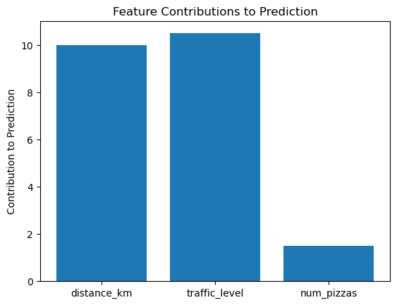

```python
plt.bar(range(len(features)), contributions)
plt.xticks(range(len(features)), [f"{name}" for name in feature_names])
plt.ylabel("Contribution to Prediction")
plt.title("Feature Contributions to Prediction")
plt.show()
```

## Beispiel: Hauspreise

Ein komplexeres Beispiel mit mehr Features: Hauspreismodell (Koeffizienten in Tausend Euro)

```python
feature_names = ["size_sqm", "bedrooms", "bathrooms", "age_years", "garage"]
coefficients = [0.3, 20.0, 15.0, -2.0, 25.0]
intercept = 50.0  # base price in thousands
```

```python
print("House Price Model:")
print("-" * 40)
for name, coef in zip(feature_names, coefficients):
    print(f"{name:15} : {coef:+8.1f}k€")
print(f"{'Base price':15} : {intercept:8.1f}k€")
```

```
House Price Model:
----------------------------------------
size_sqm        :     +0.3k€
bedrooms        :    +20.0k€
bathrooms       :    +15.0k€
age_years       :     -2.0k€
garage          :    +25.0k€
Base price      :     50.0k€
```

### Vorhersage für ein konkretes Haus

```python
house_features = [120, 3, 2, 10, 1]  # 120sqm, 3 bed, 2 bath, 10 years old, 1 garage
```

```python
print("House characteristics:")
for name, value in zip(feature_names, house_features):
    print(f"{name:15} : {value}")
```

```
House characteristics:
size_sqm        : 120
bedrooms        : 3
bathrooms       : 2
age_years       : 10
garage          : 1
```

Berechne Preis

```python
price = 0
print("\nPrice calculation:")
for name, feature, coef in zip(feature_names, house_features, coefficients):
    contribution = feature * coef
    price += contribution
    print(f"{name:15} : {feature:3} × {coef:+6.1f} = {contribution:+7.1f}k€")
```

```
Price calculation:
size_sqm        : 120 ×   +0.3 =   +36.0k€
bedrooms        :   3 ×  +20.0 =   +60.0k€
bathrooms       :   2 ×  +15.0 =   +30.0k€
age_years       :  10 ×   -2.0 =   -20.0k€
garage          :   1 ×  +25.0 =   +25.0k€
```

```python
price += intercept
print(f"{'Base price':15} :              = {intercept:+7.1f}k€")
print("-" * 45)
print(f"{'Total price':15} :              = {price:7.1f}k€")
```

```
Base price      :              =   +50.0k€
---------------------------------------------
Total price     :              =   181.0k€
```

## Zusammenfassung

- Multivariate Regression: Mehrere Features → Eine Vorhersage
- Jedes Feature hat einen Koeffizienten (Gewicht)
- Vorhersage = Summe(Feature × Koeffizient) + Intercept
- Das ist die Grundlage für komplexere Modelle!

## Nächste Schritte

- Diese Berechnungen werden schnell mühsam
- Mit vielen Features und Datenpunkten brauchen wir bessere Tools
- NumPy macht diese Berechnungen einfach und schnell
- Als Nächstes: Einführung in NumPy und Vektoren

## Workshop: Autopreise vorhersagen

Sie arbeiten für einen Gebrauchtwagenhändler und haben ein Modell zur Preisvorhersage mit folgenden Features:

### Autopreismodell

```python
car_features = ["age_years", "mileage_1000km", "engine_liters", "num_owners", "is_diesel"]
car_coefficients = [-2.5, -0.15, 8.0, -1.5, 3.0]  # in thousands of euros
car_intercept = 25.0  # base price in thousands
```

```python
print("Car Price Model (coefficients in k€):")
for feature, coef in zip(car_features, car_coefficients):
    print(f"{feature:20} : {coef:+6.2f}")
print(f"{'Base price':20} : {car_intercept:6.2f}")
```

```
Car Price Model (coefficients in k€):
age_years            :  -2.50
mileage_1000km       :  -0.15
engine_liters        :  +8.00
num_owners           :  -1.50
is_diesel            :  +3.00
Base price           :  25.00
```

### Aufgabe 1: Einzelne Vorhersage

Berechnen Sie den Preis für folgendes Auto:

- 3 Jahre alt
- 45.000 km (= 45 in Tausend km)
- 2.0 Liter Motor
- 1 Vorbesitzer
- Diesel (1 = ja, 0 = nein)

```python
car1 = [3, 45, 2.0, 1, 1]
```

Berechne Preis für car1

```python
price = 0
for feature, value, coef in zip(car_features, car1, car_coefficients):
    contribution = value * coef
    price += contribution
    print(f"{feature:20} : {value:5} × {coef:+6.2f} = {contribution:+7.2f}k€")
```

```
age_years            :     3 ×  -2.50 =   -7.50k€
mileage_1000km       :    45 ×  -0.15 =   -6.75k€
engine_liters        :   2.0 ×  +8.00 =  +16.00k€
num_owners           :     1 ×  -1.50 =   -1.50k€
is_diesel            :     1 ×  +3.00 =   +3.00k€
```

```python
price += car_intercept
print(f"{'Base price':20} :                  = {car_intercept:+7.2f}k€")
print("-" * 50)
print(f"{'Total price':20} :                  = {price:7.2f}k€")
```

```
Base price           :                  =  +25.00k€
--------------------------------------------------
Total price          :                  =   28.25k€
```

### Aufgabe 2: Mehrere Vorhersagen

Berechnen Sie die Preise für diese drei Autos:

```python
cars = [
    [5, 80, 1.6, 2, 0],  # Car A: 5 years, 80k km, 1.6L, 2 owners, petrol
    [1, 10, 3.0, 0, 1],  # Car B: 1 year, 10k km, 3.0L, 0 owners (new), diesel
    [8, 120, 1.4, 3, 0], # Car C: 8 years, 120k km, 1.4L, 3 owners, petrol
]
```

```python
car_names = ["Car A", "Car B", "Car C"]
```

```python
def predict_car_price(features, coefficients, intercept):
    """Calculate car price given features and model parameters."""
    price = sum(f * c for f, c in zip(features, coefficients))
    return price + intercept
```

```python
for name, car in zip(car_names, cars):
    price = predict_car_price(car, car_coefficients, car_intercept)
    print(f"{name}: {price:.1f}k€")
    print(f"  Features: {car}")
    print()
```

```
Car A: 10.3k€
  Features: [5, 80, 1.6, 2, 0]

Car B: 48.0k€
  Features: [1, 10, 3.0, 0, 1]

Car C: -6.3k€
  Features: [8, 120, 1.4, 3, 0]
```

### Aufgabe 3: Feature-Analyse

Welches Feature hat den größten Einfluss auf den Preis?

Berechnen Sie für Car B, welches Feature am meisten zum Preis beiträgt.

```python
car_b = cars[1]
contributions = []
```

```python
print("Car B - Feature Contributions:")
print("-" * 50)
for feature, value, coef in zip(car_features, car_b, car_coefficients):
    contribution = value * coef
    contributions.append((feature, contribution))
    print(f"{feature:20} : {value:5} × {coef:+6.2f} = {contribution:+7.2f}k€")
```

```
Car B - Feature Contributions:
--------------------------------------------------
age_years            :     1 ×  -2.50 =   -2.50k€
mileage_1000km       :    10 ×  -0.15 =   -1.50k€
engine_liters        :   3.0 ×  +8.00 =  +24.00k€
num_owners           :     0 ×  -1.50 =   -0.00k€
is_diesel            :     1 ×  +3.00 =   +3.00k€
```

```python
print(f"{'Base price':20} :{' ' * 16}= {car_intercept:+7.2f}k€")
```

```
Base price           :                =  +25.00k€
```

Finde größten Beitrag

```python
contributions.sort(key=lambda x: abs(x[1]), reverse=True)
print(f"\nLargest contribution: {contributions[0][0]} ({contributions[0][1]:+.1f}k€)")
```

```
Largest contribution: engine_liters (+24.0k€)
```